# An ODYCCEUS Tutorial for the `data.cube` Library

`data.cube` is an R package for the exploration of multidimensional datasets and for the detection of statistical outliers within. It is mainly a tool for data exploration, allowing to have a first glance at it and to formulate research hypotheses to be later tested.

The package defines a new data structure called `data.cube` that can be fed with a classical `data.frame` encoding a list of numeric observations described according to several categorical dimensions. For example, in the case of Twitter data, it can be the number of tweets (numeric observation) that have been published by a given user (first dimension) about a given topic (second dimension) at a given date (third dimension). The input `data.frame` hence takes the form of a list of quadruplets (user, topic, date, number of tweets).

Statistical outliers can then be identified among the observations by first selecting some dimensions of interest, that is by subsetting or by aggregating the input dimensions. If needed, observations can also be normalised according to the marginal values along the selected dimensions, thus comparing the observed value to an expected value obtained by the uniform redistribution of the selected marginal values. Different statistical tests can then be chosen to measure the deviation between the observed and the expected values. The package finally allows to retrieve a list of positive outliers, that is observations that are significantly higher than expected.

## Table of Contents

- An ODYCCEUS Tutorial for the `data.cube` Library
  - Installation
  - Authors and License
- Getting Started
  - Importing the dataset
  - Loading the library
  - Building the cube with `as.data.cube`
  - What’s in the cube with `summary`
  - Back to frame with `as.data.frame`
- When do we talk about what?
  - Filtering elements, renaming variables, selecting dimensions, and arranging elements
  - First plot: Focusing on the temporal dimension
  - Second plot: Looking at hashtags
  - Outlier detection: Looking at popular hashtags through time
- Who is retweeting whom?
  - Joining cubes to exploit other variables
  - Two-dimensional plotting
  - Exporting the cube to `igraph` for network analysis
- What is related to what?

## Installation

The library is not yet available on CRAN. Its source code is available on GitHub: https://github.com/Lamarche-Perrin/data.cube/blob/master/src/data.cube.R

## Authors and License

This library has been developed by researchers of the [Complex Networks](http://www.complexnetworks.fr/) team, within the [Laboratoire d’informatique de Paris 6](https://www.lip6.fr/), for the [ODYCCEUS](https://www.odycceus.eu/) project, founded by the [European Commission FETPROACT 2016-2017 program](https://ec.europa.eu/research/participants/portal/desktop/en/opportunities/h2020/calls/h2020-fetproact-2016-2017.html) under grant 732942.

Copyright © 2017-2019 Robin Lamarche-Perrin (Robin.Lamarche-Perrin@lip6.fr)

`data.cube` is free software: you can redistribute it and/or modify it under the terms of the GNU General Public License as published by the Free Software Foundation, either version 3 of the License, or (at your option) any later version. It is distributed in the hope that it will be useful, but WITHOUT ANY WARRANTY; without even the implied warranty of MERCHANTABILITY or FITNESS FOR A PARTICULAR PURPOSE. See the GN General Public License for more details. You should have received a copy of the GNU General Public License along with this program. If not, see http://www.gnu.org/licenses/.

# Getting Started

This tutorial assumes that you are familiar with the most known R packages of the [`tidyverse`](https://www.tidyverse.org/), in particular `tibble` operations provided by [`dplyr`](https://dplyr.tidyverse.org/) and the forward-pipe operator `%>%` provided by [`magrittr`](https://magrittr.tidyverse.org/).

## Importing the dataset

First, import the main file of this dataset as a `data.frame` (actually, as a `tibble`):

```r
library (readr)
df.tweets <- read_csv ('data/ODYCCEUS-migrant-crisis-tweets.csv')
df.tweets
```

```
## # A tibble: 18,061,367 x 7
##    day        from_user     type    to_user     hashtag     count weight
##    <date>     <chr>         <chr>   <chr>       <chr>       <dbl>  <dbl>
##  1 2015-01-01 031nikitaW    retweet KTLA        NULL            1  1
##  2 2015-01-01 031nikitaW    retweet Telegraph   NULL            1  1
##  3 2015-01-01 055Douglas    retweet mcspocky    Immigration     1  0.143
##  4 2015-01-01 055Douglas    retweet mcspocky    LibCrib         1  0.143
##  5 2015-01-01 055Douglas    retweet mcspocky    Politics        1  0.143
##  6 2015-01-01 055Douglas    retweet mcspocky    TNTweeters      1  0.143
##  7 2015-01-01 055Douglas    retweet mcspocky    TopProg         1  0.143
##  8 2015-01-01 055Douglas    retweet mcspocky    UniteBlue       1  0.143
##  9 2015-01-01 055Douglas    retweet mcspocky    p2              1  0.143
## 10 2015-01-01 07246361jorge retweet BBCBreaking NULL            1  1
## # … with 18,061,357 more rows
```

- First column `day` contains publication dates of the tweets (`YYYY-MM-DD` format).
- Second column `user` contains account names of users that have published the tweets. Accounts with less than 1000 followers have been anonymised (for example `user12345`).
- Third column `type` indicates the type of tweet: `tweet`, `reply`, or `retweet`.
- Fourth column `to_user` contains the account names of users that have been replied to (if `type == 'reply'`), or that have been retweeted (if `type == 'retweet'`), or `NULL` in the case of an original tweet (if `type == 'tweet'`).
- Fifth column `hashtag` indicates eventual hashtags within the tweets (`NULL` if no hashtag).
- Sixth column `count` indicates the corresponding number of tweets, that is the number of tweets published by `user` during `day` of `type` relating `to_user` and containing `hashtag`.
- Seventh column `weight` takes into account the fact that several hashtags might appear in the same tweet, and so that such a tweet might hence be counted several times. In this regard, a tweet containing `n` different hashtags is weighted by `1/n` and then distributed among `n` lines. Summing this last columns hence gives the exact number of tweets (contrary to the `count` column).

## Loading the library

First, load the library:

```r
source ('data.cube.R')
# or library (data.cube) when it will be available as a proper R package
```

## Building the cube with `as.data.cube`

```r
dc.tweets <-
    df.tweets %>% as.data.cube (
               dim.names = list (day, from_user, type, to_user, hashtag),
               var.names = list (tweets = weight, count),
               sup.dim.names = list (user = list (from_user, to_user))
           )
```

## What’s in the cube with `summary`

Function `summary` then prints a short summary of the data contained in the resulting structure.

```r
dc.tweets %>% summary (verbose = TRUE)
```

```
## data.cube of 6 dimensions and 2 variables
##
## -> Dimension day
##  - Element number: 353
##  - Class (type):   Date (double)
##  - Element names:  2015-01-01, 2015-01-02, 2015-01-03, 2015-01-04, 2015-01-05, ...
##
## -> Dimension user
##  - Element number: 3123171
##  - Class (type):   character (character)
##  - Element names:  031nikitaW, 055Douglas, 07246361jorge, 0fficialCR7, ...
##
## -> Dimension type
##  - Element number: 3
##  - Class (type):   character (character)
##  - Element names:  retweet, tweet, reply
##
## -> Dimension hashtag
##  - Element number: 245664
##  - Class (type):   character (character)
##  - Element names:  NULL, Immigration, LibCrib, Politics, TNTweeters, TopProg, ...
##
## -> Dimension from_user
##  - Sub-dimension of user
##
## -> Dimension to_user
##  - Sub-dimension of user
##
## -> Variable tweets
##  - Dimensions:   day x from_user x type x to_user x hashtag
##  - Class (type): numeric (double)
##  - NA value:     num 0
##
## -> Variable count
##  - Dimensions:   day x from_user x type x to_user x hashtag
##  - Class (type): numeric (double)
##  - NA value:     num 0
```

## Back to frame with `as.data.frame`

Function `as.data.frame` transforms a `data.cube` object back into a `data.frame` object (actually, a `tibble`).

```r
dc.tweets %>% as.data.frame ()
```

```
## # A tibble: 18,061,367 x 7
##    day        from_user     type    to_user     hashtag     tweets count
##  * <date>     <chr>         <chr>   <chr>       <chr>        <dbl> <dbl>
##  1 2015-01-01 031nikitaW    retweet KTLA        NULL         1         1
##  2 2015-01-01 031nikitaW    retweet Telegraph   NULL         1         1
##  3 2015-01-01 055Douglas    retweet mcspocky    Immigration  0.143     1
##  4 2015-01-01 055Douglas    retweet mcspocky    LibCrib      0.143     1
##  5 2015-01-01 055Douglas    retweet mcspocky    Politics     0.143     1
##  6 2015-01-01 055Douglas    retweet mcspocky    TNTweeters   0.143     1
##  7 2015-01-01 055Douglas    retweet mcspocky    TopProg      0.143     1
##  8 2015-01-01 055Douglas    retweet mcspocky    UniteBlue    0.143     1
##  9 2015-01-01 055Douglas    retweet mcspocky    p2           0.143     1
## 10 2015-01-01 07246361jorge retweet BBCBreaking NULL         1         1
## # … with 18,061,357 more rows
```

# When do we talk about what?

This first `data.cube` and its 5 dimensions are a bit tedious for a first analysis. The library provide simple tools for subsetting the data and begin the exploration along fewer dimensions. In this section, we hence focus on the analysis of the temporal popularity of hashtags by only selecting the `day` and `hashtag` dimensions: “*When* do we talk about *what*?”

## Filtering elements, renaming variables, selecting dimensions, and arranging elements

In the script below:

- `filter.elm (type, name == 'tweet')` filters out elements of dimension `type` which are not tweets (*i.e.*, filters out replies and retweets);
- `rename.var (tweets = documents)` renames variable `documents` with new name `tweets`;
- `select.dim (day, hashtag)` selects dimensions `day` and `hashtag` for the following analysis (*i.e.*, aggregate the data along other dimensions `from_user`, `to_user`, and `type`);
- `arrange.elm.by.name ()` arranges elements of all dimensions according to their name (in lexicographic order).

```r
dc.day.hashtag <-
    dc.tweets %>%
    filter.elm (type, type == 'tweet') %>%
    select.dim (day, hashtag) %>%
    arrange.elm.by.name ()

dc.day.hashtag %>% summary ()
```

```
## data.cube of 2 dimensions and 2 variables
## - dim day     ->    353 elms (Date)
## - dim hashtag -> 245664 elms (character)
## - var tweets  -> day x hashtag (numeric)
## - var count   -> day x hashtag (numeric)
```

```r
dc.day.hashtag %>% as.data.frame ()
```

```
## # A tibble: 1,079,500 x 4
##    day        hashtag               tweets count
##    <date>     <chr>                  <dbl> <dbl>
##  1 2015-01-01 シンクビー              0.25     1
##  2 2015-01-01 エイネーション          0.25     1
##  3 2015-01-01 ユルブリンナー          1        1
##  4 2015-01-01 01_January              1        1
##  5 2015-01-01 1amThoughts             1        1
##  6 2015-01-01 1u                      1        1
##  7 2015-01-01 1U                      0.5      1
##  8 2015-01-01 24HrsOfRadissonSweeps   2        4
##  9 2015-01-01 2A                      1.29     3
## 10 2015-01-01 2nd                     0.5      1
## # … with 1,079,490 more rows
```

## First plot: Focusing on the temporal dimension

We now have a two-dimensional `data.cube` containing all hashtags through time appearing in the corpus’ tweets. First, one can select dimension `day` and plot variable `tweets` with function `plot.var` to have an aggregated representation of the number of published tweets each day (regardless of the hashtags they contain).

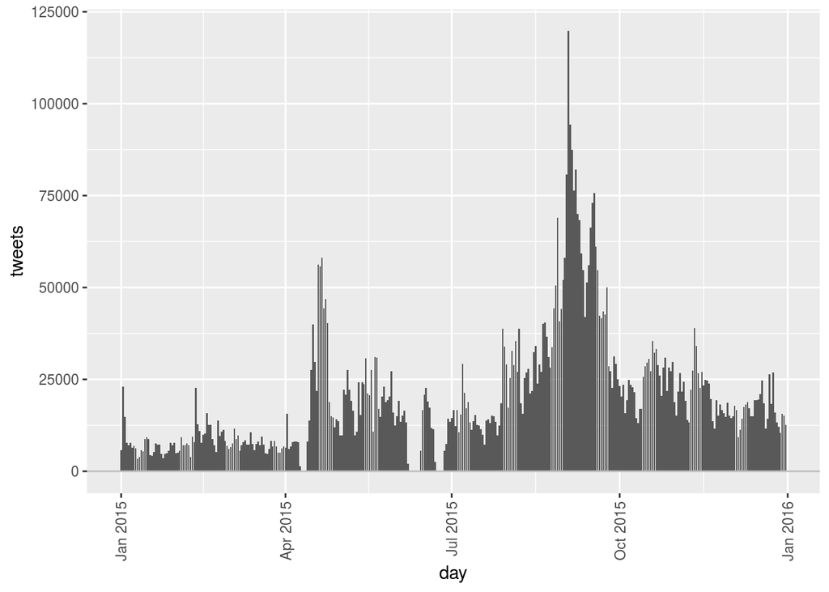

```r
dc.day.hashtag %>%
    select.dim (day) %>%
    ggplot.var (tweets)
```

Note that function `group.day.elm` easily allows to change the temporal resolution of a `data.cube` containing a dimension `day`. A parameter indicates the name of the replacing temporal dimension: `dim.name %in% c ('week', 'month', 'year')`.

Also note that function `plot.var` returns a `ggplot` object that can hence be customised accordingly. Below, we use `scale_x_date` to change the date labels on the x-axis and `ggtitle` to add a title to the plot.

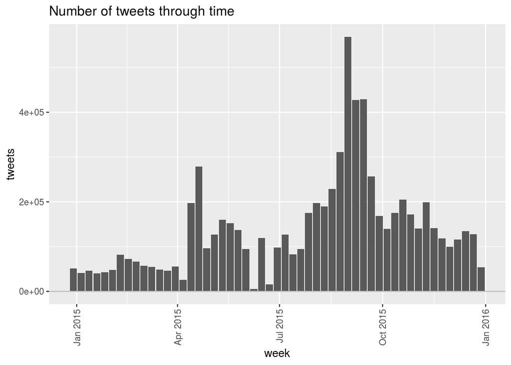

```r
dc.day.hashtag %>%
    select.dim (day) %>%
    group.day.elm (week) %>%
    ggplot.var (tweets) +
    ggtitle ("Number of tweets through time")
```

## Second plot: Looking at hashtags

We now look at the second dimension of our `data.cube`, that is the dimension of hashtags (regardless of publication dates). In the script below:

- `filter.elm (hashtag, ! name %in% hashtags.to.remove, name != 'NULL')` filters out hashtags that belongs to a user-defined list (those corresponding to keywords that were used to collect the initial corpus) and also removes hashtag `NULL` (corresponding to tweets in the corpus that do not contain any hashtag).
- `top_n.elm (hashtag, tweets, n = 20)` retains the 20 hashtags that appear in the most tweets;
- `arrange.elm (hashtag, desc (tweets))` arranges the retained hashtag with respect to the number of tweets in which they appear (in decreasing order).

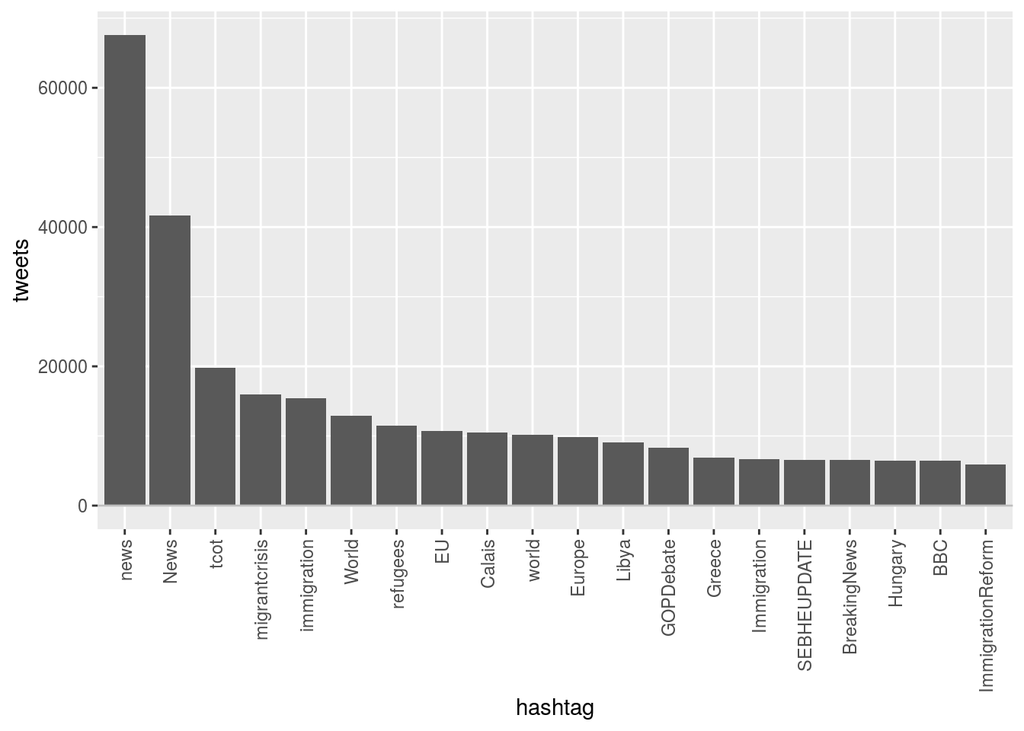

```r
hashtags.to.remove <- c ('NULL', 'emigrant', 'emigrants', 'immigrant', 'immigrants', 'migrant', 'migrants', 'Emigrant', 'Emigrants', 'Immigrant', 'Immigrants', 'Migrant', 'Migrants')

dc.hashtag <-
    dc.day.hashtag %>%
    select.dim (hashtag) %>%
    filter.elm (hashtag, ! hashtag %in% hashtags.to.remove) %>%
    top_n.elm (hashtag, tweets, n = 20) %>%
    arrange.elm (hashtag, desc (tweets))

dc.hashtag %>% ggplot.var (tweets)
```

## Outlier detection: Looking at popular hashtags through time

The `data.cube` library offers simple tools for outlier detection in multidimensional data. Let’s look for dates when given hashtags are particularly popular (*cf.* country names in script below).

```r
hashtags.of.interest <- c ('Iran', 'Iraq', 'Kosovo', 'Eritrea', 'Nigeria', 'Lybia')

dc.day.hashtag.subset <-
    dc.day.hashtag %>%
    filter.elm (hashtag, hashtag %in% hashtags.of.interest) %>%
    arrange.elm (hashtag, desc (tweets)) %>%
    group.day.elm (week)
```

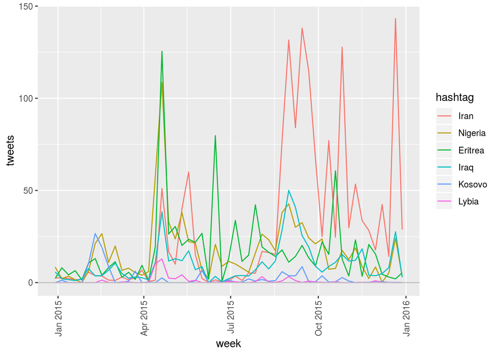

```r
dc.day.hashtag.subset %>%
    ggplot.var (tweets, sep.dim.names = hashtag, type = 'line')
```

Finding outliers in the plot above is problematic. Because hashtag `Iran` is much more present than other ones, most curves look quite low. Indeed, if one get the aggregated tweet number of selected hashtags (regardless of publication dates), one notice that they globally have quite different levels of popularity on the whole corpus (*e.g,* `Iran` appears in 12 times more tweets than `Kosovo`).

```r
dc.day.hashtag.subset %>%
    select.dim (hashtag) %>%
    as.data.frame
```

```
## # A tibble: 5 x 3
##   hashtag tweets counts
##   <chr>    <dbl>  <dbl>
## 1 Iran     3016.   7649
## 2 Eritrea  1196.   2393
## 3 Nigeria  1184.   2409
## 4 Iraq      930.   3061
## 5 Kosovo    241.    526
```

Finding outliers hence requires to first define an “expectation model” to which observations must then be compared. There are multiple ways of defining such a model. For a start, one can take into account the aggregated values above to build expected values.

In the script below, function `mutate.var.model` applied on variable `tweets` with parameter `tweets (hashtags)` defines a model which (i) projects the variable onto dimension `hashtag` (*i.e.*, aggregates dimension `week`), (ii) get the resulting tweet number for each hashtag, (iii) uniformly distributes this aggregated variable within dimension `week` to obtain an average value. It results in the computation of a new variable, `tweets.model <- tweets (hashtag) / elm.nb (week)`, which is displayed in the following plot.

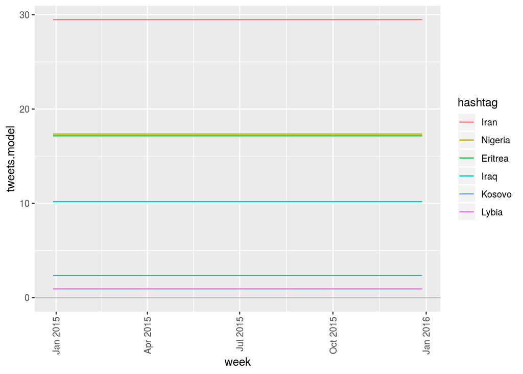

```r
dc.day.hashtag.subset %>%
    complete.elm () %>%
    mutate.var.model (tweets, tweets (hashtag)) %>%
    ggplot.var (tweets.model, sep.dim.names = hashtag, type = 'line')
```

Using this computed model, function `mutate.var.deviation` then computes a third variable, `tweets.deviation`, which indicates to which extent observations deviate from the model. With no additional parameter, the deviation is given by a simple ratio `tweets.deviation <- tweets / tweets.model`.

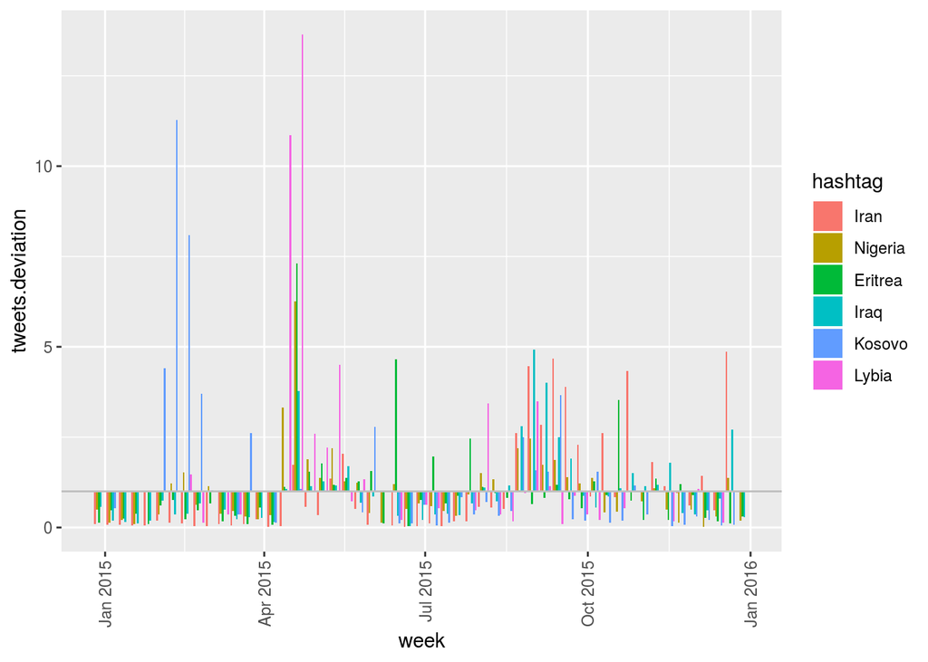

```r
dc.day.hashtag.subset %>%
    mutate.var.model (tweets, tweets (hashtag)) %>%
    mutate.var.deviation (tweets, deviation.type = "ratio") %>%
    ggplot.var (tweets.deviation, sep.dim.names = hashtag, type = 'bar')
```

Note that ratio does not account for the significativity of a deviation. Indeed, observing a value of `4` when expecting `2` is equivalent to observing a value of `400` when expecting `200`, although the former might easily be caused by insignificant statistical variations while the latter is much more reliable. Function `mutate.var.deviation` can hence be adjusted with parameter `deviation.type %in% c ('ratio', 'poisson', 'chisq', 'KLdiv')` to use other deviation measures which take into account the significativity of such deviations.

For example, in the script below, `deviation.type = 'chisq'` indicates to use a measure based on the Chi-squared test: `tweets.deviation <- (tweets - tweets.model)^2 / tweets.model`.

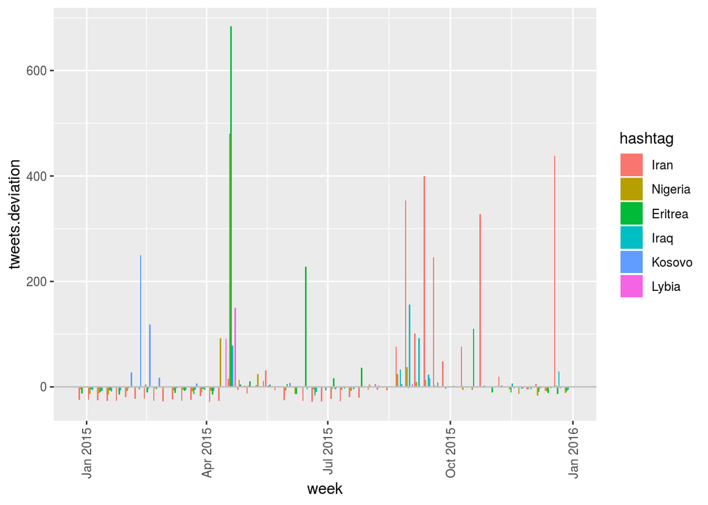

```r
dc.day.hashtag.subset %>%
    mutate.var.model (tweets, tweets (hashtag)) %>%
    mutate.var.deviation (tweets, deviation.type = 'chisq') %>%
    ggplot.var (tweets.deviation, sep.dim.names = hashtag, type = 'bar')
```

It then appears in the plot above that `Kosovo` indeed shows less outliers that computed before when accounting for the statistical significativity of such outliers.

# Who is retweeting whom?

This next section deals with another subset of the `data.cube` dimensions, that is the retweet relation between users: “*Who* is retweeting *whom*?”

## Joining cubes to exploit other variables

This variable is first imported from another `data.frame`.

```r
df.users <- read_csv ('data/ODYCCEUS-migrant-crisis-users.csv')
df.users
```

```
## # A tibble: 4,738,408 x 3
##    user           tweetcount followercount
##    <chr>               <dbl>         <dbl>
##  1 user1                  50            43
##  2 user2                  98            10
##  3 user3                 162            67
##  4 ALLYSJAUREGUll      21768          2122
##  5 user4                4713           550
##  6 amandinechlt        28182          4636
##  7 stylespedreiro      93426          2545
##  8 rifatbasaran         1812          2225
##  9 user5               13598            61
## 10 user6                9460            34
## # … with 4,738,398 more rows
```

One can now build a uni-dimensional `data.cube` from the imported `data.frame` and join it with our first `data.cube` with function `join`. It results in a `data.cube` of 5 dimensions (as before) with a total of 4 variables (2 of them being defined on dimension `user` only).

```r
dc.users <-
    df.users %>%
    as.data.cube (
        dim.names = user,
        var.names = list (tweetcount, followercount)
    )

dc.tweets <- dc.tweets %>% join (dc.users)
dc.tweets %>% summary ()
```

```
## data.cube of 6 dimensions and 4 variables
## - dim day           ->     353 elms (Date)
## - dim user          -> 4738410 elms (character)
## - dim type          ->       3 elms (character)
## - dim hashtag       ->  245664 elms (character)
## - dim from_user     (see user)
## - dim to_user       (see user)
## - var tweets        -> day x from_user x type x to_user x hashtag (numeric)
## - var count         -> day x from_user x type x to_user x hashtag (numeric)
## - var tweetcount    -> user (numeric)
## - var followercount -> user (numeric)
```

We now check the number of users that have more than 5000 followers.

```r
dc.tweets %>% filter.elm (user, followercount >= 5000) %>% elm.nb (user)
```

```
## [1] 165875
```

We finally use function `group.elm` to aggregate together all users that have less than 5000 followers within a new element named `OTHER_USERS`. This drastically reduces the size of dimension `user` while keeping marginal information about the variables (contrary to function `filter.elm` which would have simply removed these users, along with all associated observations).

```r
dc.from_user.to_user <-
    dc.tweets %>%
    filter.elm (type, type == 'retweet') %>%
    rename.var (retweets = tweets) %>%
    group.elm (user, OTHER_USERS, followercount < 5000) %>%
    select.dim (from_user, to_user)

dc.from_user.to_user %>% summary ()
```

```
## data.cube of 3 dimensions and 4 variables
## - dim user          -> 165876 elms (character)
## - dim from_user     (see user)
## - dim to_user       (see user)
## - var retweets      -> from_user x to_user (numeric)
## - var count         -> from_user x to_user (numeric)
## - var tweetcount    -> user (numeric)
## - var followercount -> user (numeric)
```

## Two-dimensional plotting

When projected onto dimension `user`, variable `retweets` now leads to two different variables: `retweets.from_user`, which corresponds to the number of retweets published by user, and `retweets.to_user`, which corresponds to the retweet number of tweets published by a given user. The former could be interpreted as the *activity* of users (as broadcasters) and the latter as the *popularity* of users (as authors).

In the script below, function `biplot.var` allows to plot these two variables one against the other to explore the activity and popularity levels of a subset of users.

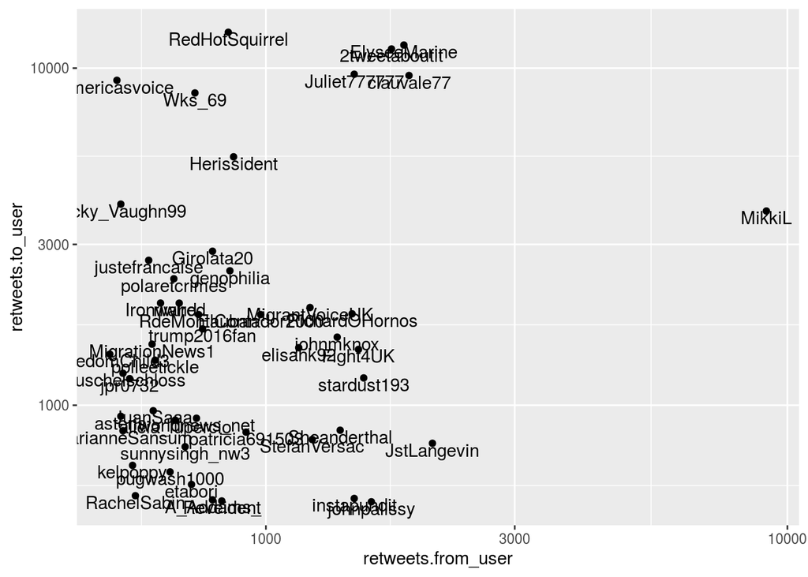

```r
dc.from_user.to_user %>%
    select.dim (user) %>%
    filter.elm (user, retweets.from_user >= 500, retweets.to_user >= 500, user != 'OTHER_USERS') %>%
    ggplot.vars (retweets.from_user, retweets.to_user, log = 'xy')
```

## Exporting the cube to `igraph` for network analysis

Function `as.igraph` allows to transform a two-dimensional `data.cube` into an `igraph` object, which can then serve for network analysis.

```r
igraph.user <-
    dc.from_user.to_user %>%
    filter.elm (user, user != 'OTHER_USERS') %>%
    as.igraph (from_user, to_user, edge.weight = retweets)
```

Because a graph of `vcount (igraph.user) == 165875` nodes is difficult to plot, in the script below, we use function `cluster_louvain` from the `igraph` library to group users into communities (*i.e.*, densely connected groups of nodes, see https://igraph.org/r/doc/cluster_louvain.html for detailed documentation). The resulting data structure hence associates a community index to each user.

```r
communities <-
    igraph.user %>%
    as.undirected (mode = 'collapse', edge.attr.comb = sum) %>%
    cluster_louvain ()

membership (communities) %>% sample (4)
```

```
## AmericansOrg  Drr_EmamAli    Crai9y335    ThaiTopRT
##         2863        61352        11563        47084
```

In order to label these communities, we also use function `pagerank` from the `igraph` library to measure the level of importance of each user in the network (see https://igraph.org/r/doc/page_rank.html for detailed documentation).

```r
pagerank <- page_rank (igraph.user)

pagerank$vector %>% sample (4)
```

```
##         RawnnaC Labiblesurlenet        alloyent     MadgieAvery
##    2.993008e-06    2.993008e-06    2.993008e-06    2.993008e-06
```

Using function `join`, we add the two newly computed variables to our `data.cube` for later use.

```r
dc.from_user.to_user <-
    dc.from_user.to_user %>%
    join (
        membership (communities) %>% as.data.cube (user),
        pagerank$vector %>% as.data.cube (user, pagerank)
    )

dc.from_user.to_user %>% summary
```

```
## data.cube of 3 dimensions and 6 variables
## - dim user          -> 165876 elms (character)
## - dim from_user     (see user)
## - dim to_user       (see user)
## - var retweets      -> from_user x to_user (numeric)
## - var counts        -> from_user x to_user (numeric)
## - var tweetcount    -> user (numeric)
## - var followercount -> user (numeric)
## - var community     -> user (numeric)
## - var pagerank      -> user (numeric)
```

```r
dc.from_community.to_community <-
    dc.from_user.to_user %>%
    group.elm.by.var (
        user, community,
        label = user [order (desc (pagerank)) [1:4]] %>% paste0 (collapse = '\n'),
        size = n()
    ) %>%
    rename.dim (from_community = from_user, to_community = to_user)

dc.from_community.to_community %>% summary
```

```
## data.cube of 3 dimensions and 7 variables
## - dim community      -> 61788 elms (numeric)
## - dim from_community (see community)
## - dim to_community   (see community)
## - var retweets       -> from_community x to_community (numeric)
## - var counts         -> from_community x to_community (numeric)
## - var tweetcount     -> community (numeric)
## - var followercount  -> community (numeric)
## - var pagerank       -> community (numeric)
## - var label          -> community (character)
## - var size           -> community (integer)
```

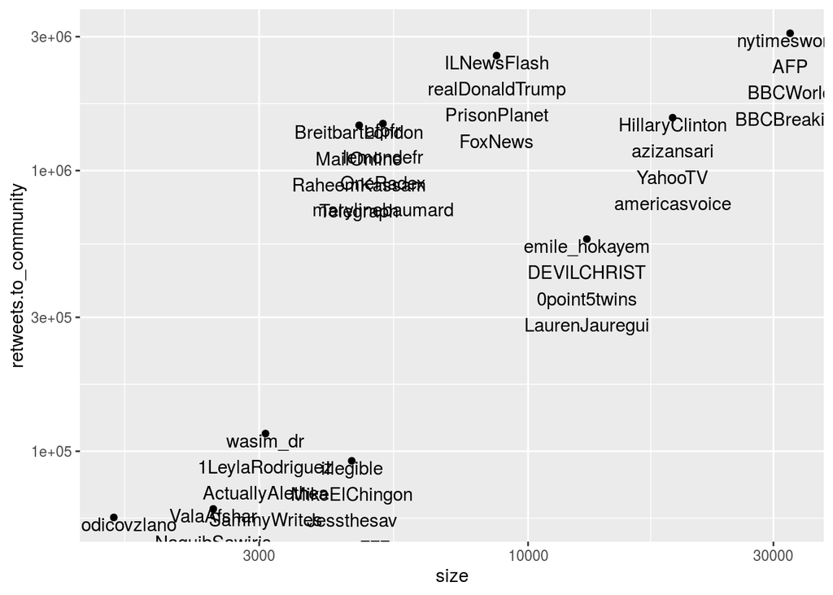

```r
dc.from_community.to_community %>%
    select.dim (community) %>%
    filter.elm (community, size > 1000, community != 'OTHER_USERS') %>%
    mutate.var (community, community = label) %>%
    ggplot.vars (size, retweets.to_community, log = 'xy')
```

As shown in the plot below (computed with the `ggplot` library), there are many small communities and few big ones.

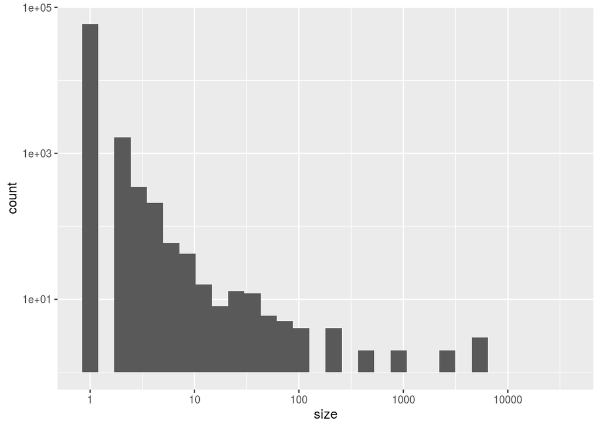

```r
dc.from_community.to_community %>%
    as.data.frame (community) %>%
    ggplot (aes (x = size)) +
    geom_histogram () + scale_x_log10 () + scale_y_log10 ()
```

We hence extract community containing more than 1000 users (with variable `size`) and export the resulting aggregated network as an `igraph` object.

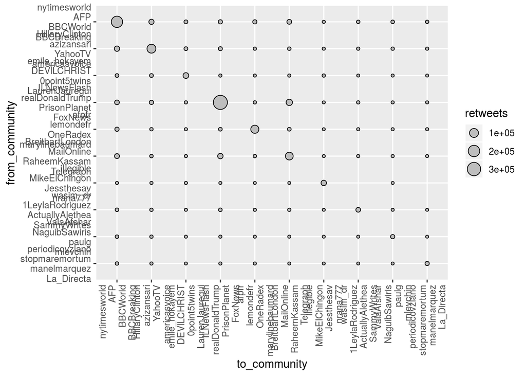

```r
dc.from_community.to_community %>%
    filter.elm (community, size >= 1000) %>%
    arrange.elm (community, desc (size)) %>%
    mutate.var (community, community = label) %>%
    ggplot.var (retweets, sep.dim.names = from_community, type = "point")
```

```r
igraph.community <-
    dc.from_community.to_community %>%
    filter.elm (community, size >= 1000) %>%
    mutate.var (community, community = label) %>%
    as.igraph (from_community, to_community, vertex.size = size, edge.weight = retweets)
```

Finally, one can display the result (here using the `ForceAtlas2` layout algorithm).

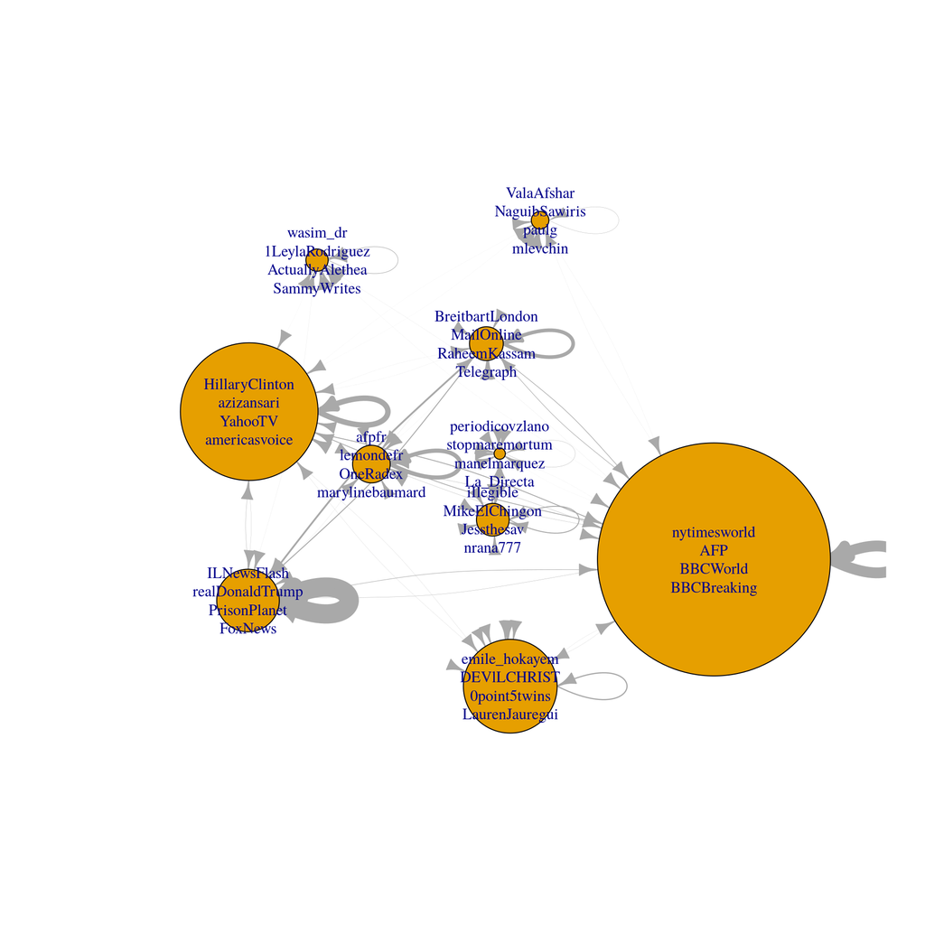

```r
library (ForceAtlas2)
set.seed (4)

vertex.size <- 100 * V(igraph.community)$size / max (V(igraph.community)$size)
edge.weight <- 20 * E(igraph.community)$weight / max (E(igraph.community)$weight)

vertex.coordinate <-
    igraph.community %>%
    layout.forceatlas2 (k = 200, gravity = 5000, iterations = 2000, plotstep = 0, linlog = TRUE)

igraph.community %>%
    plot (
        layout = vertex.coordinate,
        vertex.size = vertex.size,
        edge.curved = 0.1,
        edge.width = edge.weight,
    )
```

# What is related to what?

```r
dc.month.user <-
    dc.tweets %>%
    filter.elm (type, type %in% c ('tweet', 'reply')) %>%
    filter.elm (user, followercount >= 1000 | user == 'NULL') %>%
    filter.elm (hashtag, hashtag != 'NULL') %>%
    transmute.var (text = hashtag, size = 1) %>%
    group.day.elm (month) %>%
    select.dim (month, from_user)

dc.month.user %>% as.data.frame ()
```

```
## # A tibble: 250,658 x 4
##    month      from_user     text                                       size
##    <date>     <chr>         <chr>                                     <dbl>
##  1 2015-01-01 0ozes         openbordersforisrael                          1
##  2 2015-01-01 1954candanga  Italy Italy China Syria BREAKING World C…     8
##  3 2015-01-01 1catherinesi… tcot tcot Catholic ccot PRAY persecution…     7
##  4 2015-01-01 24NewsLive    News News News News News News News News …     9
##  5 2015-01-01 2ANow         2A 2A 2A 2A 2A 2A 2A 2A 2A 2A 2A 2A 2A 2…    15
##  6 2015-01-01 2tweetaboutit UKIP UKIP UKIP UKIP opendoorimmigration …     6
##  7 2015-01-01 365Arizona    TeaParty TeaParty TeaParty TeaParty TeaP…    38
##  8 2015-01-01 4nnak         OperacaoBetaLab OperacaoBetaLab Operacao…    27
##  9 2015-01-01 52DNorth      ModernBritain                                 1
## 10 2015-01-01 55krissi55    bbcnews RoadToRuin FinishTheTories Torie…     9
## # … with 250,648 more rows
```

```r
dc.month.user %>%
    as.json () %>%
    write ('data/ODYCCEUS-migrant-crisis-hashtags-1000.json')
```